# Practical 4

Matteo Larrode

2023-10-26

# Week 4: Randomised Experiments: Inference and External Validity

```r
library(tidyverse)
library(randomizr)

load("data/practical4_data.Rda")
```

**a) Using a simple regression, calculate the ATE and its p-value from the experiment, ignoring blocking (suppose we didn’t realise this was a block-randomised experiment). Store the ATE as an object**

```r
summary(lm(Y ~ Z, data = a))
```

```
##
## Call:
## lm(formula = Y ~ Z, data = a)
##
## Residuals:
##    Min     1Q Median     3Q    Max
## -8.000 -3.571 -1.286  4.857  8.429
##
## Coefficients:
##             Estimate Std. Error t value Pr(>|t|)
## (Intercept)   10.000      2.109   4.741 0.000479 ***
## Z             -6.429      2.983  -2.155 0.052165 .
## ---
## Signif. codes:  0 '***' 0.001 '**' 0.01 '*' 0.05 '.' 0.1 ' ' 1
##
## Residual standard error: 5.581 on 12 degrees of freedom
## Multiple R-squared:  0.279,  Adjusted R-squared:  0.219
## F-statistic: 4.644 on 1 and 12 DF,  p-value: 0.05217
```

```r
ate <- summary(lm(Y ~ Z, data = a))$coef[2]
```

The ATE is -6.43 with a p-value of 0.052

**b) Calculate the number of possible unique treatment vectors that can arise in this experiment, which has 7 treatment units and 7 control units.**

*Code Hint: Use the formula for combinations with replacement in the lecture slides, together with R’s factorial() command*

```r
combinations <- factorial(14)/(factorial(7)*factorial(14-7))
```

There are 3,432 possible unique treatment vectors

**c) Using the following code, create a matrix of all possible permutations of treatment assignment, ignoring the blocking (it may take 1-2 minutes to run). Verify that it gives you the correct number, as calculated in (b).**

```r
perms <- unique(replicate(50000,complete_ra(14)),MARGIN=2)

dim(perms)
```

```
## [1]   14 3432
```

There should be 3,432 permutations of the treatment vector

**d) Now, create the null distribution of ATEs using the permutations matrix:**

1. Create an empty vector called “ates” using ates <- c().

```r
ates <- c()
```

2. Using a for() loop, fill in this vector with the ATE under each possible permutation of treatment

```r
# My first version
col_outcome <- a$Y
perms_df <- as.data.frame(perms)

calc_ate <- function(treatment, outcome) {
  new_df <- tibble(treatment, outcome)
  ate <- summary(lm(outcome ~ treatment, data = new_df))$coef[2]

  return(ate)
}


for (i in colnames(as.data.frame(perms))) {
  ates[i] <- calc_ate(perms_df[[i]], col_outcome)
}

# Solution version
for (i in 1:ncol(perms)) {
  ates[i] <- mean(a$Y[perms[, i] == 1]) - mean(a$Y[perms[, i] == 0])
}
```

Here, we took the Y vector, which under the sharp null contains all of the potential outcomes under treatment and control: the observed outcomes are the full set of potential outcomes, because it doesn’t matter whether someone is assigned to treatment or control.

We then used Y to calculate the ATE under every possible randomisation, telling us the null distribution of possible ATEs. This allows us to ask: under the null, how likely is our ATE to arise by chance alone, merely due to the quirks of randomisation?

**e) Calculate the exact two-tailed p-value using: the estimated ATE from (a) and the null distribution from (d). Give a precise interpetation of it. Is it higher or lower than the p-value calculated the traditional way in (a)?**

*Hint: Calculate the proportion of the null distribution that is at least as extreme as the estimated ATE.*

```r
(length(ates[ates<=ate]) + length(ates[ates>=-ate])) / ncol(perms)
```

```
## [1] 0.06118881
```

The exact p-value is 0.061. It implies that if the strict null hypothesis were true, we’d observe an ATE at least as large as our actual ATE 6.1% of the time across all possible randomisations usinf a two-tailed test. The p-value is higher than in (a), which is very common when conducting randomisation inference.

**f) To visualise what is happening, plot the null distribution as a density or histogram, adding vertical lines for the estimated ATE and critical values for the exact two-tailed hypothesis test with a significance level of 5%**

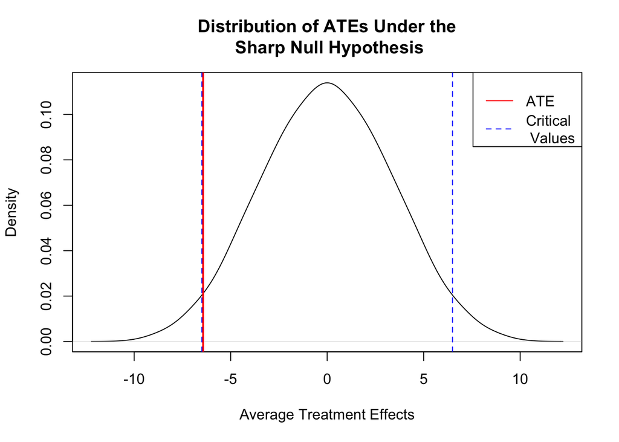

```r
plot(density(ates),
       xlab="Average Treatment Effects",
       main="Distribution of ATEs Under the\n Sharp Null Hypothesis")
abline(v=ate,col="red",lwd=2)
abline(v=quantile(ates,0.025),col="blue",lty=2)
abline(v=quantile(ates,0.975),col="blue",lty=2)
legend("topright",c("ATE","Critical\n Values"),lty=c(1,2),col=c("red","blue"),ncol=1)
```

**g) Finally, let’s re-estimate everything, this time accounting for the blocking. First, calculate the ATE and its p-value from the experiment, accounting for the blocking. Is it different to (a)?

```r
reg2 <- lm(Y~Z + factor(block),data=a)

summary(reg2)
```

```
##
## Call:
## lm(formula = Y ~ Z + factor(block), data = a)
##
## Residuals:
##     Min      1Q  Median      3Q     Max
## -5.7857 -0.6429  0.3393  1.9509  3.2143
##
## Coefficients:
##                Estimate Std. Error t value Pr(>|t|)
## (Intercept)       6.089      1.255   4.851  0.00051 ***
## Z                -6.429      1.514  -4.247  0.00137 **
## factor(block)2    9.125      1.530   5.966 9.38e-05 ***
## ---
## Signif. codes:  0 '***' 0.001 '**' 0.01 '*' 0.05 '.' 0.1 ' ' 1
##
## Residual standard error: 2.832 on 11 degrees of freedom
## Multiple R-squared:  0.8298, Adjusted R-squared:  0.7988
## F-statistic: 26.81 on 2 and 11 DF,  p-value: 5.895e-05
```

```r
ate2 <- reg2$coef[2]
```

The ATE is unchanged but the p-value has fallen a lot compared to (a), to 0.0014 as we would expect: blocking allows us to estimate the same ATE with much greater precision

**Using the following code2, create a new matrix of all possible permutations of treatment assignments with the blocking (again it may take 1-2 minutes to run).**

*The difference to part (c) is that we include the actual block assignments within the code block ra, which creates block randomisations instead of the standard randomisations from (c)*

```r
perms2 <- unique(replicate(20000,block_ra(a$block)),MARGIN=2)

dim(perms2)
```

```
## [1]   14 1400
```

There are now 1400 possible permutations compared to the 3432 in (b). This shows how blocking reduces the number of possible randomisations.

**i) Repeat (d) to (f), this time using the permutations matrix from question (h). Comment on how the null distribution has changed, compared to (f)**

```r
ates2 <- c()

for (i in 1:ncol(perms2)) {
  ates2[i] <- mean(a$Y[perms2[, i] == 1]) - mean(a$Y[perms2[, i] == 0])
}

(length(ates2[ates2 <= ate2]) + length(ates2[ates2 >= -ate2])) / ncol(perms2)
```

```
## [1] 0.002857143
```

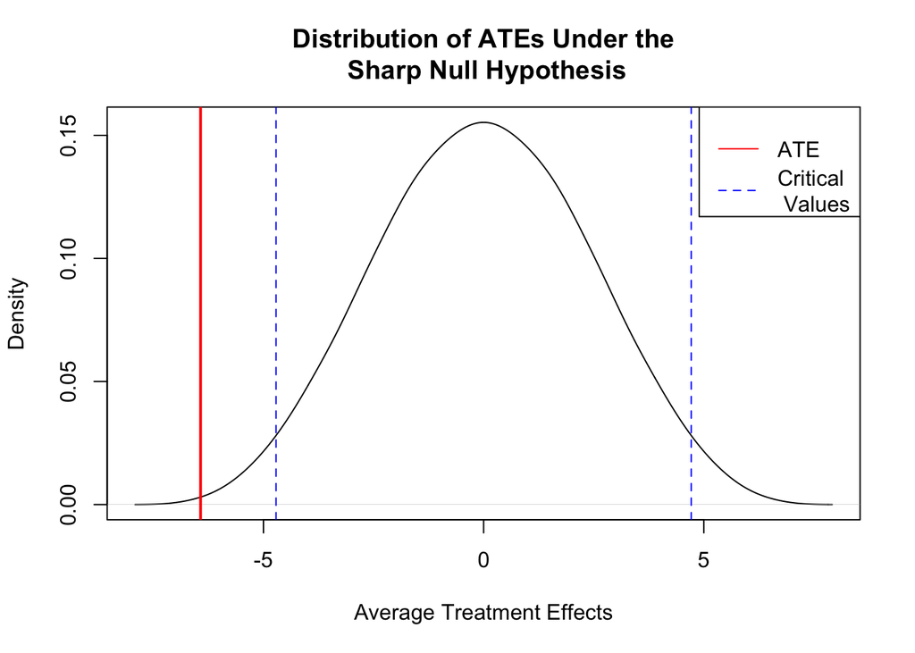

```r
plot(density(ates2),
  xlab = "Average Treatment Effects",
  main = "Distribution of ATEs Under the\n Sharp Null Hypothesis"
)
abline(v = ate2, col = "red", lwd = 2)
abline(v = quantile(ates2, 0.025), col = "blue", lty = 2)
abline(v = quantile(ates2, 0.975), col = "blue", lty = 2)
legend("topright", c("ATE", "Critical\n Values"), lty = c(1, 2), col = c("red", "blue"), ncol = 1)
```

The null distribution is much narrower, with fewer extreme values compared to (f). Remem- ber that blocking is useful because it rules out ‘crazy’ randomisations that result in extreme ATEs. This exercise demonstrates it directly.